# Neural networks and hand-written image recognition

**Author:** Leonardo Espin

Date: 1/10/2019

```python
import pandas as pd
import numpy as np
import seaborn as sns
import matplotlib.pyplot as plt
import matplotlib.image as mpimg #to work with raster images
%matplotlib inline
```

- The dataframe `XDF` contains image data that has been flattened to vectors. It contains 5000 training examples of images of 20x20 pixels (a vector of 400 elements)
- The dataframe `yDF` contains the labels for each image. The images corresponding to zero, have been labeled as 10
- A neural network with a single hidden layer, with 25 *activation units* has been trained to classify the images according to the label. The weights of the hidden layer $\theta_{1,0},\dots,\theta_{1,400},\theta_{2,0},\dots,\dots,\theta_{25,400}$ are in the dataframe `theta1DF`, and the weights of the output layer are in `theta2DF`

This is a subset of the MNIST handwritten digit dataset

```python
XDF=pd.read_csv('ex3data1-X.csv',header=None)
yDF=pd.read_csv('ex3data1-y.csv',header=None)
theta1DF=pd.read_csv('ex3weights-T1.csv',header=None)
theta2DF=pd.read_csv('ex3weights-T2.csv',header=None)
```

```python
print(XDF.shape)
XDF.head()
```

```
(5000, 400)
```

|  | 0 | 1 | 2 | 3 | 4 | 5 | 6 | 7 | 8 | 9 | ... | 390 | 391 | 392 | 393 | 394 | 395 | 396 | 397 | 398 | 399 |
| --- | --- | --- | --- | --- | --- | --- | --- | --- | --- | --- | --- | --- | --- | --- | --- | --- | --- | --- | --- | --- | --- |
| 0 | 0 | 0 | 0.0 | 0.0 | 0.0 | 0.0 | 0.0 | 0.0 | 0.0 | 0.0 | ... | 0.0 | 0.0 | 0.0 | 0.0 | 0.0 | 0.0 | 0.0 | 0.0 | 0.0 | 0 |
| 1 | 0 | 0 | 0.0 | 0.0 | 0.0 | 0.0 | 0.0 | 0.0 | 0.0 | 0.0 | ... | 0.0 | 0.0 | 0.0 | 0.0 | 0.0 | 0.0 | 0.0 | 0.0 | 0.0 | 0 |
| 2 | 0 | 0 | 0.0 | 0.0 | 0.0 | 0.0 | 0.0 | 0.0 | 0.0 | 0.0 | ... | 0.0 | 0.0 | 0.0 | 0.0 | 0.0 | 0.0 | 0.0 | 0.0 | 0.0 | 0 |
| 3 | 0 | 0 | 0.0 | 0.0 | 0.0 | 0.0 | 0.0 | 0.0 | 0.0 | 0.0 | ... | 0.0 | 0.0 | 0.0 | 0.0 | 0.0 | 0.0 | 0.0 | 0.0 | 0.0 | 0 |
| 4 | 0 | 0 | 0.0 | 0.0 | 0.0 | 0.0 | 0.0 | 0.0 | 0.0 | 0.0 | ... | 0.0 | 0.0 | 0.0 | 0.0 | 0.0 | 0.0 | 0.0 | 0.0 | 0.0 | 0 |

5 rows × 400 columns

```python
print(theta1DF.shape)
print(theta2DF.shape)
theta2DF.head()
```

```
(25, 401)
(10, 26)
```

|  | 0 | 1 | 2 | 3 | 4 | 5 | 6 | 7 | 8 | 9 | ... | 16 | 17 | 18 | 19 | 20 | 21 | 22 | 23 | 24 | 25 |
| --- | --- | --- | --- | --- | --- | --- | --- | --- | --- | --- | --- | --- | --- | --- | --- | --- | --- | --- | --- | --- | --- |
| 0 | -0.76100 | -1.21240 | -0.10187 | -2.36850 | -1.05780 | -2.208200 | 0.56384 | 1.21110 | 2.21030 | 0.44456 | ... | -0.23366 | -1.5201 | 1.15320 | 0.10368 | -0.37208 | -0.61530 | -0.12568 | -2.271900 | -0.71836 | -1.29690 |
| 1 | -0.61785 | 0.61559 | -1.26550 | 1.85750 | -0.91853 | -0.055026 | -0.38590 | 1.29520 | -1.56840 | -0.97026 | ... | -2.44170 | -0.8563 | -0.29826 | -2.07950 | -1.29330 | 0.89982 | 0.28307 | 2.311800 | -2.46440 | 1.45660 |
| 2 | -0.68934 | -1.94540 | 2.01360 | -3.12320 | -0.23618 | 1.386800 | 0.90982 | -1.54770 | -0.79831 | -0.65600 | ... | -1.63900 | 1.2027 | -1.20250 | -1.83450 | -1.88010 | -0.34056 | 0.23692 | -1.061400 | 1.02760 | -0.47691 |
| 3 | -0.67832 | 0.46299 | 0.58492 | -0.16502 | 1.93260 | -0.229660 | -1.84730 | 0.49012 | 1.07150 | -3.31910 | ... | -0.68428 | -1.6471 | 0.21153 | -0.27422 | 1.72600 | 1.32420 | -2.63980 | -0.080559 | -2.03510 | -1.46120 |
| 4 | -0.59664 | -2.04480 | 2.05700 | 1.95100 | 0.17638 | -2.161400 | -0.40395 | 1.80160 | -1.56280 | -0.25253 | ... | -0.67489 | 1.1407 | 1.32430 | 3.21160 | -2.15890 | -2.60160 | -3.22260 | -1.896100 | -0.87488 | 2.51040 |

5 rows × 26 columns

The images correspond to hand drawn digits (0 to 9), and they can be shown with the `imshow` command:

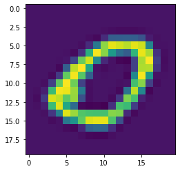

```python
tmp=XDF.iloc[0,:].values.reshape(20,20)
plt.imshow(tmp);
```

Below I show a mozaic of a 100 images selected at random from the training samples (notice that the bitmap arrays have to be transposed to be shown correctly):

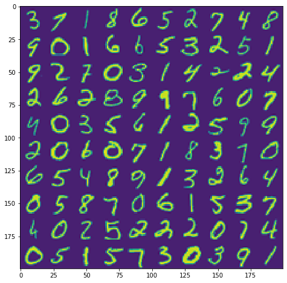

```python
import random
#select a 100 images (rows) at random
selection=[random.randint(0,5000) for x in range(100)];

image=np.zeros((20*10, 20*10)) #for constructing a mozaic of 10x10 images
coords=[(x,y) for x in range(1,11) for y in range(1,11)];
for k,tup in enumerate(coords):
    indYa=0+20*(tup[0]-1)
    indYb=19+20*(tup[0]-1)
    indXa=0+20*(tup[1]-1)
    indXb=19+20*(tup[1]-1)
    image[indYa:indYb+1,indXa:indXb+1]=XDF.iloc[selection[k],:].values.reshape(20,20).transpose()

plt.figure(figsize=(8,8))
plt.imshow(image);
```

The structure of the trained neural network is shown below

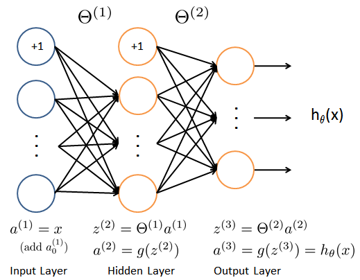

Below I apply the neural network to the training set in `XDF`. Note that colums or rows of ones have to be added to the flattened images to account for the *bias units*

```python
#add a column (axis=1) of ones (3rd argument) to the image data (1st argument) at
#the beggining of the matrix (2nd argument)
X=np.insert(XDF.values, 0, 1, axis=1)
X[0:5,0:15]
```

```
array([[1., 0., 0., 0., 0., 0., 0., 0., 0., 0., 0., 0., 0., 0., 0.],
       [1., 0., 0., 0., 0., 0., 0., 0., 0., 0., 0., 0., 0., 0., 0.],
       [1., 0., 0., 0., 0., 0., 0., 0., 0., 0., 0., 0., 0., 0., 0.],
       [1., 0., 0., 0., 0., 0., 0., 0., 0., 0., 0., 0., 0., 0., 0.],
       [1., 0., 0., 0., 0., 0., 0., 0., 0., 0., 0., 0., 0., 0., 0.]])
```

Multiplying each image by the hidden layer weights to obtain the $z$ values:

```python
Z2=np.matmul(theta1DF.values,X.transpose())
print(Z2.shape)
```

```
(25, 5000)
```

The values $a^{(2)}_i$, $i=1,\dots,25$ are obtained by applying the sigmoid function (notice that the function is vectorized and applied simultaneously to the whole `Z2` matrix):

```python
def g(z):
    return 1/(1+np.exp(-z))

g = np.vectorize(g)
```

```python
A2=g(Z2)
print(A2.shape)
A2[0:3,0:5]
```

```
(25, 5000)
```

```
array([[0.0503631 , 0.00805789, 0.01419626, 0.04589353, 0.00188314],
       [0.07939735, 0.05105084, 0.02443577, 0.00361582, 0.07777682],
       [0.99300211, 0.93367502, 0.99751863, 0.99569588, 0.98854938]])
```

a row of ones is added to the matrix `A2` to account for the *bias unit*

```python
A2=np.insert(A2, 0, 1, axis=0)
A2[0:4,0:5]
```

```
array([[1.        , 1.        , 1.        , 1.        , 1.        ],
       [0.0503631 , 0.00805789, 0.01419626, 0.04589353, 0.00188314],
       [0.07939735, 0.05105084, 0.02443577, 0.00361582, 0.07777682],
       [0.99300211, 0.93367502, 0.99751863, 0.99569588, 0.98854938]])
```

Below are the calculations for the output layer, which has 10 nodes corresponding to the 10 categories of the hand-written symbols

```python
Z3=np.matmul(theta2DF.values,A2)
A3=g(Z3)
print(A3.shape)
print('clasification results of first 4 images (choose max value per column):')
A3[0:10,0:4]
```

```
(10, 5000)
clasification results of first 4 images (choose max value per column):
```

```
array([[1.12671887e-04, 4.79056232e-04, 8.85776815e-05, 5.57383895e-05],
       [1.74148916e-03, 2.41533708e-03, 3.24329935e-03, 8.05061830e-03],
       [2.52662295e-03, 3.44724408e-03, 2.55394811e-02, 1.78282512e-02],
       [1.84041460e-05, 4.05623351e-05, 2.13624508e-05, 8.65244918e-05],
       [9.36362070e-03, 6.53492371e-03, 3.96943735e-03, 6.42347222e-04],
       [3.99261936e-03, 1.75928814e-03, 1.02875046e-02, 1.14645561e-02],
       [5.51521866e-03, 1.15783184e-02, 3.86827771e-04, 1.85173645e-03],
       [4.01439251e-04, 2.39088978e-03, 6.22854803e-02, 4.69276085e-03],
       [6.48144766e-03, 1.97051630e-03, 5.49898509e-03, 8.21379857e-04],
       [9.95733748e-01, 9.95696578e-01, 9.28004235e-01, 9.94103811e-01]])
```

```python
classification=np.argmax(A3,axis=0)
classification
```

```
array([9, 9, 9, ..., 8, 8, 8])
```

Below I show a few classification results chosen at random

```
learned value = 2
```

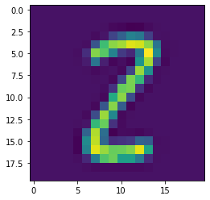

```
learned value = 7
```

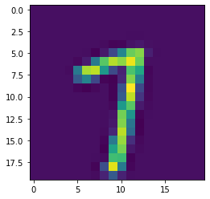

```
learned value = 10
```

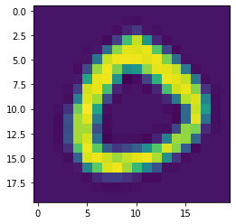

```
learned value = 7
```

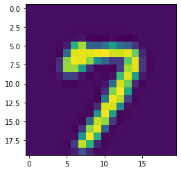

```python
import time

for _ in range(4):
    k=random.randint(0,100)
    k=selection[k]
    print('learned value = {}'.format(classification[k]+1))
    tmp=XDF.iloc[k,:].values.reshape(20,20).transpose()
    plt.imshow(tmp,animated=True)
    plt.show()
    time.sleep(1.5)
```

The overall classification accuracy is:

```python
accuracy=(100*sum(classification.reshape(yDF.values.shape) == yDF.values-1)
          /len(classification))[0]
print('classification accuracy: {}%'.format(accuracy))
```

```
classification accuracy: 97.52%
```

### Using scikit-learn to train the classification Neural Network

```python
from sklearn.neural_network import MLPClassifier

#the solver chosen below works better with small sets. otherwise use
#stochastic gradient descent or other options
clf = MLPClassifier(solver='adam',              #adam is the default
                    alpha=1e-3,                 #reg. parameter lambda =1/(2*500)
                    hidden_layer_sizes=(25,),   #1 hidden layer with 25 units
                    activation='logistic',      #the logistic sigmoid function, could change to relu
                    #max_iter=400,
                    validation_fraction=0.2)
```

```python
clf.fit(XDF.values, yDF.values.flatten())#flatten reshapes the 5000x1 col matrix to 1D array
                                         #otherwise sklearn complaints
```

```
MLPClassifier(activation='logistic', alpha=0.001, batch_size='auto', beta_1=0.9,
              beta_2=0.999, early_stopping=False, epsilon=1e-08,
              hidden_layer_sizes=(25,), learning_rate='constant',
              learning_rate_init=0.001, max_iter=200, momentum=0.9,
              n_iter_no_change=10, nesterovs_momentum=True, power_t=0.5,
              random_state=None, shuffle=True, solver='adam', tol=0.0001,
              validation_fraction=0.2, verbose=False, warm_start=False)
```

The learned coefficients are below. Notice that we obtain a very high classification accuracy because in this example we are training with just 5000 images (8% of entire dataset), so the model is most likely overfitting.

```python
T1=clf.coefs_[0]
T2=clf.coefs_[1]
print(T1.shape)
print(T2.shape)
print('theta_0 coefficients:')
print(clf.intercepts_[0].shape)
print(clf.intercepts_[1].shape)
```

```
(400, 25)
(25, 10)
theta_0 coefficients:
(25,)
(10,)
```

```python
accuracy=(100*sum(clf.predict(XDF.values).reshape(yDF.values.shape) == yDF.values)
          /len(classification))[0]
print('classification accuracy: {}%'.format(accuracy))
```

```
classification accuracy: 98.88%
```

```python
#or more easily
clf.score(XDF.values, yDF.values)
```

```
0.9888
```

A Keras DNN trained on the entire dataset can be seen here: Keras and the MNIST dataset